# 01.3 Button Lab

This is the basic building blocks for the Python Tkinter window.

- Contents:
  1. Google Slides Link
  2. Repl.it Link
  3. Lab Overview - What is required.

     a. GUI Solution - This is what the final outcome should look like.

     b. READ.ME File - This is the objectives and rubric.

     c. Build.ME file- This is the code needed to complete the lab.

This lab and Google Slides covers the following content:

- Button
- Button Parameters

# 1. Google Slides

[Tkinter Button Widget Slides](https://docs.google.com/presentation/d/1icdWFzf7xaeEr97zoFI4bZjoCxUHdEqL54JAy_M-KgM/edit?usp=sharing)

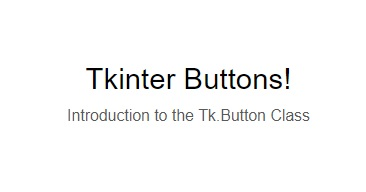

# 01.3 Button Repl.it

[Tkinter Button Widget Slides](https://replit.com/join/ytxiuocv-erniedrumm)

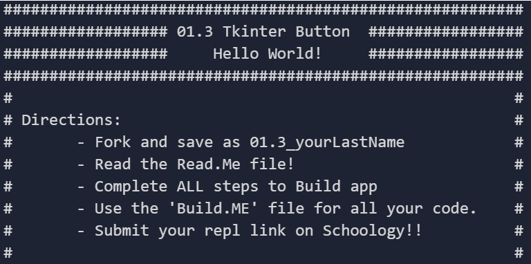

Top

# 3. Lab 01.3 Overview

- Use Build.ME file to construct main.py file.
- Complete each example 1-4
- Customize each Button and associated attributes.

## a. GUI Solution for 01.3 Button Lab

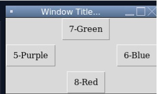

Top

## b. The 'READ.ME' File

### This is a required read through because this file includes the directions, steps, objectives, point values, and rubric.

```python
#########################################################
################## 01.3 Tkinter Button  #################
##################     Hello World!     #################
#########################################################
#                                                       #
# Directions:                                           #
#       - Fork and save as 01.3_yourLastName            #
#       - Read the Read.Me file!                        #
#       - Complete ALL steps to Build app               #
#       - Use the 'Build.ME' file for all your code.    #
#       - Submit your repl link on Schoology!!          #
#                                                       #
#  --------------------------------------------------   #
# Essential Setup Steps:                                #
#     Setup: Enter comments for Name, Date, Lab desc.   #
#     1. import * (ALL) the tkinter libraries           #
#     2. The Tk() class instance                        #
#     3. The .geometry method                           #
#     4. The .title method                              #
#     5. The .mainloop method                           #
#                                                       #
#  --------------------------------------------------   #
# Objectives:                                           #
#      1. Ensure the main.py file runs with the basic   #
#           python Tkinter libraries and window.        #
#      2. Run each example 1-4                          #
#      3. Customize each Button and associated          #
#          attributes.                                  #
#                                                       #
#  --------------------------------------------------   #
# New Python Content:                                   #
#           Button                                      #
#           Button Parameters                           #
#                                                       #
#  --------------------------------------------------   #
# Point Values:                                         #
#        Comments:                                      #
#                   name, date, description   5         #
#                                                       #
#        Runs as intended:                    5         #
#                                                       #
#        Change Button text:                  5         #
#                                                       #
#        Add additional Button/s:             5         #
#                                                       #
#        Modify Button placement:             5         #
#                                                       #
#                                            25 Total   #
#                                                       #
#  --------------------------------------------------   #
#  Rubric:                                              #
#                                                       #
#      Update Comments                                  #
#               0-1           2-3          4-5          #
#          ------------   ------------   ------------   #
#               No         Some           Lots of       #
#            Comments       Comments       comments     #
#               No         Little         Lots of       #
#             Updates        Detail        details      #
#                                         Updated       #
#                                                       #
#                                                       #
#      Runs as Intended                                 #
#              0-1           2-4             5          #
#         ------------   ------------   ------------    #
#         Does not run   Runs with      Runs with no    #
#          or no code     errors or      errors.        #
#          and/or wrong   unexpected    Runs as intended#
#          code.          results.      Additional      #
#                                        features do not#
#                                        effect app     #
#                                                       #
#                                                       #
#      Change Button Text                               #
#              0-1           2-4             5          #
#         ------------   ------------   ------------    #
#         No button or   Spelling       New text is     #
#          does not say   issues or      present and    #
#          anything.      not in         can see in the #
#                         button         GUI window.    #
#                                                       #
#                                                       #
#      Add additional Button                            #
#              0-1           2-4             5          #
#         ------------   ------------   ------------    #
#         No button      Missing one    Additional      #
#          added or not   part or not    button works   #
#          working at     working        as intended.   #
#          all.           correctly.    No errors.      #
#                         OR incorrect                  #
#                         button format.                #
#                                                       #
#                                                       #
#                                                       #
#      Modify Button placement                          #
#              0-1           2-4             5          #
#         ------------   ------------   ------------    #
#         No changes to  Missing one    Width and Height#
#          the height     of the         created and set#
#          or width in    settings for   correctly.     #
#                         height or                     #
#                         width. OR                     #
#                        Wrong width or                 #
#                         height numbers                #
#                                                       #
#########################################################
```

## c. The 'Build.ME' File

### This file includes all the code necessary to get the lab up and running. It is divided into important sections.

```python
# Objectives.
#   1. Ensure basic window works.
#   2. Add code and run each example 1-4.
#       a. Button basic
#       b. Button attributes (font, relief)
#       c. Multiple Buttons, attribute (command)
#       b. Multiple Buttons attributes (pady, activeforeground, activebackground) and .pack() method.

"""  # Example 1.  Button

myButton = Button(root, text="Button-1")
myButton.pack()

"""




"""  # Example 2  Font, relief

myButton = Button(root, text="Button-2", fg = "red", font = "Verdana 14 underline", bd = 2, bg = "light blue", relief = "groove")
myButton.pack()
myButton.pack()

"""




"""   # Example 3 Multiple Buttons, Command to exit


myButton_3 = Button(root, text="Button 3", fg = "yellow", font="Times", bd = 2, bg="purple", relief = "groove")
myButton_3.pack()

myButton_4 = Button(root, text="Button 4", fg = "red", font="Times", bd = 2, bg="gray", relief = "sunken", command=root.destroy)
myButton_4.pack()

"""




""" #  Example 4: Multiple buttons placed around Window

myButton_5 = Button(root, text="5-Purple", activeforeground="yellow", activebackground="purple", font="Times", pady=10)
myButton_5.pack(side=LEFT)

myButton_6 = Button(root, text="6-Blue", activeforeground="yellow", activebackground="blue", font="Times", pady=10)
myButton_6.pack(side=RIGHT)

myButton_7 = Button(root, text="7-Green", activeforeground="orange", activebackground="green", font="Times", pady=10)
myButton_7.pack(side=TOP)

myButton_8 = Button(root, text="8-Red", activeforeground="yellow", activebackground="red", font="Times", pady=10, command=root.destroy)
myButton_8.pack(side=BOTTOM)


"""
```

Top

## Resources

#### Sources and deeper learning research:

1. Python Tkinter Canvas Widget. Studytonight Technologies Pvt. Let. 2021. 3/30/2021. https://www.studytonight.com/tkinter/python-tkinter-canvas-widget
1. W3Schools.com - [Python GUI Programming](https://www.w3schools.in/python-tutorial/gui-programming/)
1. RepL.it. https://replit.com/~

Top